# **Introducción a R y Rstudio**

R es un lenguaje de programación estadístico de código abierto que se creó en la década de 1990 específicamente para el análisis de datos. R es un lenguaje y entorno de software para estadísticas y gráficos. R Studio proporciona una interfaz amigable para trabajar con R, facilitando la escritura, depuración y ejecución de código, además de ofrecer herramientas adicionales para la visualización de datos y la generación de informes.

### Beneficios de R Studio:

**Interfaz gráfica amigable**: R Studio tiene una interfaz de usuario intuitiva que facilita la escritura y ejecución de código R.

**Herramientas integradas**: Ofrece herramientas integradas para la visualización de datos, depuración de código, y la creación de informes reproducibles.

**Soporte para Shiny**: Permite desarrollar aplicaciones interactivas basadas en R con Shiny.

**Integración con Git**: Facilita el control de versiones y colaboración en proyectos.

### Atajos de teclado que pueden ser útiles:

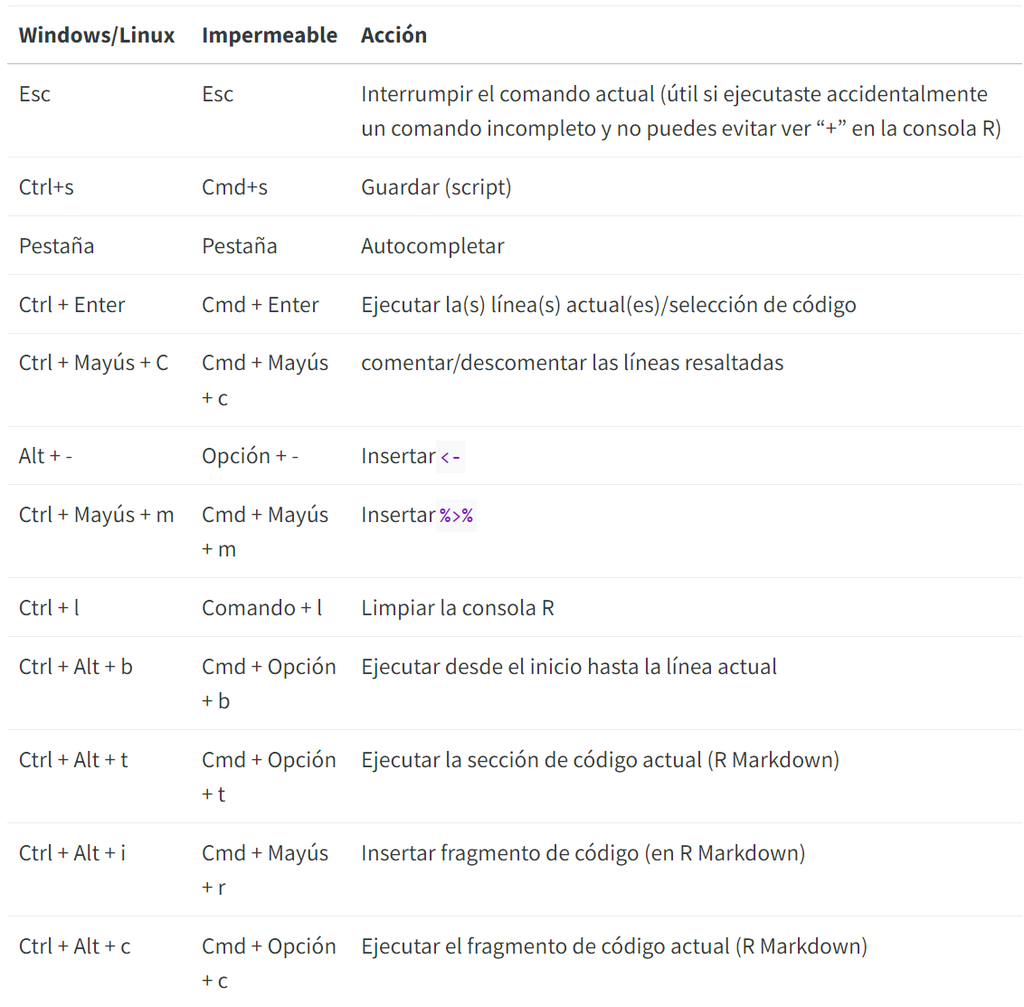

Para más atajos se puede acceder a su página web:

[Atajos de teclado en Rstudio](https://docs.posit.co/ide/user/ide/reference/shortcuts.html)

# **Operaciones básicas en R**

Operadores Matemáticos en R Se puede usar R como una calculadora

- Suma: +
- Resta: -
- Multiplicación: *
- División: /
- Módulo (Residuo): %%(En R, el operador de resto o módulo se utiliza para obtener el residuo de una división entre dos números)

```r
3+5  #Sumamos
```

```
[1] 8
```

```r
3-2   #restamos
```

```
[1] 1
```

```r
3/2   #dividimos
```

```
[1] 1.5
```

```r
3*2   #multiplicamos
```

```
[1] 6
```

```r
3^2   #elevamos al cuadrado
```

```
[1] 9
```

```r
3**2  #elevamos al cuadrado
```

```
[1] 9
```

```r
9%%4  #operador resto
```

```
[1] 1
```

#### Precedencia de los opeadores

Como toda operación matemática, existe una precedencia de los operadores, esto quiere decir que en una ecuación que involucra muchos operadores unos tienen prioridad de resolución.

El orden de resolución esta definido por

- () primero se resuelven los paréntesis
- ** luego se resuelven la potencias
- (* o /) después las multiplicaciones o divisiones
- (+ o -) por último las sumas y restas

```r
# Ejemplo de como funciona la precedencia de los operadores:


3+2*5
```

```
[1] 13
```

```r
(3+2)*5
```

```
[1] 25
```

```r
2/8**2
```

```
[1] 0.03125
```

# **Objetos en R**

Todos los lenguajes de programación necesitan almacenar información para poder luego usarla. En R toda información se guarda en objetos y disponemos de varios tipos, los más empleados son:

- Variables
- Vectores
- Listas
- Factores
- Matrices
- Data frames

Veremos sobre todo algunos de ellos para pasar a ver como se utilizan en las funciones.

## **Variables**

Una variable en programación es un espacio de almacenamiento con un nombre simbólico (un identificador) que se refiere o está asociado a un valor o información almacenada.

Se pueden pensar como cajas que tiene una etiqueta que es el nombre de la variable. Dentro de la caja podemos guardar diferentes tipos de datos, como números, texto entre otros.

```r
# Ejercicio 1: Crear una variable llamada 'edad' y asignarle el valor 25

edad <- 25

# Imprimir el valor de la variable 'edad'

print(edad)
```

```
[1] 25
```

**`edad <- 25 :`** aquí el simbolo **`<-`** se utiliza para asigna un valor a la nueva variable que estoy creando.

**`print(edad):`** Esto se utiliza para imprimir el resultado de la acción de asignación

También si queremos acceder al valor de esa variable podemos hacerlo simplemente escribiendo el nombre de esa variable.

```r
edad
```

```
[1] 25
```

### Tipos de variables

- **Numeric:** incluyen números
- **Character:** son variables que almacenan cadena de texto
- **Logical**: almacenan un valor Verdadero (TRUE) o falso (FALSE). Es a menudo el resultado de operaciones lógicas
- **Date:** guardan una cadena de texto que R interpreta como una fecha

```r
# Vemos ejemplos de Tipos de variables

a <- 10 #creamos una variable numérica

A <- "meses" #Creamos una variable de caracteres

b <- TRUE #Creamos una variable lógica (FALSE)

c <- Sys.Date() #Creamos una variable Fecha (tomamos la fecha del ordenador con la función Sys.Date())

a
```

```
[1] 10
```

```r
A
```

```
[1] "meses"
```

```r
b
```

```
[1] TRUE
```

```r
c
```

```
[1] "2024-10-09"
```

Para observar la estructura de los datos que tengo puedo utilizar la función **`srt()`** o **`class()`** para que R me indique que tipo de variables tengo:

```r
 #Investigamos la estructura de los objetos creados con la función

str(a)
```

```
 num 10
```

```r
str(A)
```

```
 chr "meses"
```

```r
str(b)
```

```
 logi TRUE
```

```r
str(c)  #Investigamos el tipo de variable los objetos creados con la función class()
```

```
 Date[1:1], format: "2024-10-09"
```

```r
class(a)
```

```
[1] "numeric"
```

```r
class(A)
```

```
[1] "character"
```

Las variables pueden utilizarse en operaciones matemáticas y lógicas en R.

```r
# Por ejemplo para calcular el área de un rectánguloa utilizando las variable

longitud <- 5

ancho <- 3

area <- longitud * ancho  # Imprimir el resultado

print(paste("El área del rectángulo es:",area))
```

```
[1] "El área del rectángulo es: 15"
```

Aquí arriba el **`paste()`** concatena la linea de caracteres **`"El área del rectángulo es:"`** con el valor del cálculo del área. Y `print()` lo impirme para que podamos verlo.

## **Vectores**

### Vectores numéricos

Un vector es un grupo elementos ordenados, todos deben ser del mismo tipo (todos números o todos caracteres por ejemplo). La forma más simple de crear un vector es usando la función **`c()`** y separando por comas a los elementos que lo forman:

```r
# Ejercicio n°3 crear un vector. El objeto vector

a <- c(1,2,3,4) #creamos un vector de 4 elementos

c <- c(a, 7,8,9)#creamos un vector uniendo uno que ya existe

a
```

```
[1] 1 2 3 4
```

```r
c
```

```
[1] 1 2 3 4 7 8 9
```

También se puede pegar vectores:

```r
#Concatenar dos vectores

a<-c(1,2,6) #creamos un vector

b<-c(4,5) #creamos otro vector

c <- c(a,b)#concatenamos ambos vectores

c
```

```
[1] 1 2 6 4 5
```

Tambien se puede armar un vector de la siguiente manera:

```r
a<-c(1:4) #Es lo mismo que escribir

c(1,2,3,4)
```

```
[1] 1 2 3 4
```

### Vectores de caracteres

Se pueden crear vectores de carcateres. Deberían notar que los nombres de los vectores que se crean aparecen en el **entorno global**.

También se puede notar que en el panel de entorno global muestra información adicional sobre este vector, a la derecha de su nombre. Específicamente, debería ver chr [1:4] “Carlos”,“Luisa”,“Bruno”,“Ana”

```r
 # Ejemplo de vector con nombres

nombres <- c("Carlos","Luisa","Bruno","Ana")

# Imprimir resultado
nombres
```

```
[1] "Carlos" "Luisa"  "Bruno"  "Ana"
```

### Operaciones básicas con vectores

Dado un vector podemos estar interesados en obtener datos sobre su contenido y que de algún modo lo resuma. Si queremos conocer medidas estadísticas de los elementos del vector tenemos las siguientes funciones:

- **length**: nos retorna un valor que indica la longitud (cantidad de elementos) del vector
- **sum**: nos devuelve un valor con la suma de los elementos
- **mean**: nos dice la media de los elementos del vector
- **sd**: retorna un valor indicando el desvío estandar
- **median**: no devuelve la mediana

```r
# Ejercicio n°4: genere un vector y conozca sus medidas estadísticas

a<-c(1:5)   #creamos un vector para analizar estadísticas

length(a)   #Nos dice la longitud (cantidad de elementos) de un vector
```

```
[1] 5
```

```r
sum(a)      #suma todos los elementos del vector
```

```
[1] 15
```

```r
mean(a)     #nos dice la media de los elementos del vector
```

```
[1] 3
```

```r
sd(a)       #nos dice el desvío
```

```
[1] 1.581139
```

```r
median(a)   #...la mediana
```

```
[1] 3
```